# UMAMI RECEPTOR PROJECT

# ANTICIPATED IMAGE

Following these PAML analyses, I will use R to construct a primate phylogeny which will document type of selection (negative, neutral or positive) on each primate branch (see Image 2 for the image of inspiration). I anticipate importing a phylogenetic tree into R, then I will use packages such as ggtree in R to modify the tree. As in my inspiration image, I anticipate using color coordinated node labels to indicate negative, neutral or positive selection on that branch. This can be done in R. As far as the vertical group labels, I will attempt to find functions in R to acheive this look, although at this moment I am unaware of such functions or aesthetics. However, if I am unable to produce this in R, I will export the image with its colored nodes then make the subsequent additions (the side label groupings) in powerpoint.

# REFERENCES

Bielawski, Joseph P. “Detecting the signatures of adaptive evolution in protein-coding genes.” Current protocols in molecular biology. January 15, 2013, 101. DOI: https://doi.org/10.1002/0471142727.mb1901s101.

Bielawski, Joseph P., Jennifer L. Baker, and Joseph Mingrone. “Inference of episodic changes in natural selection acting on protein coding sequences via CODEML.” Current protocols in bioinformatics. June 20, 2016, 54. DOI: https://doi.org/10.1002/cpbi.2.

DeCasien, A. R., Williams, S. A., & Higham, J. P. “Primate brain size is predicted by diet but not sociality.” Nature ecology & evolution, 2017, 1(5). DOI: https://doi.org/10.1038/s41559-017-0112.

Diepeveen, J., Moerdijk‐Poortvliet, T. C., & van der Leij, F. R. “Molecular insights into human taste perception and umami tastants: A review.” Journal of Food Science, 2022, 87(4). DOI: https://doi.org/10.1111/1750-3841.16101.

Ferraro, Joseph V., Thomas W. Plummer, Briana L. Pobiner, James S. Oliver, Laura C. Bishop, David R. Braun, Peter W. Ditchfield et al. “Earliest archaeological evidence of persistent hominin carnivory.” PloS one 8, April 25, 2013, 4. DOI:10.1371/journal.pone.0062174.

Izar, P., Peternelli-dos-Santos, L., Rothman, J. M., Raubenheimer, D., Presotto, A., Gort, G., … & Fragaszy, D. M. (2022). “Stone tools improve diet quality in wild monkeys.” Current Biology, 2022, 32(18). DOI: https://doi.org/10.1016/j.cub.2022.07.056.

Leonard, William. R., Josh J. Snodgrass, and Marcia L. Robertson. “Effects of brain evolution on human nutrition and metabolism.” Annu. Rev. Nutr, August 21, 2007, 27. DOI: 10.1146/an- nurev.nutr.27.061406.093659.

Toda, Yasuka, et al. “Evolution of the primate gluatamate taste sensor from a nucleotide sensor.” Current Biology. October 25, 2021, 31. DOI:https://doi.org/10.1016/j.cub.2021.08.002.

Watts, David P. “Eating eating by nonhuman primates: A review and synthesis.” Journal of Human Evolution. October 24, 2020, 149. DOI:Https://doi.org/10.1016/j.jhevol.2020.102882.

Wu, Yonghua, Haifeng Wang, Haitao Wang, and Elisabeth A. Hadly. “Rethinking the origin of primates by reconstructing their diel activity patterns using genetics and morphology.” Scientific Reports, September 19 2017, 7(1). DOI: https://doi.org/10.1038/s41598-017-12090-3.

Zhang, Jianan, Dongxiao Sun-Waterhouse, Guowan Su, & Mouming Zhao. “New insight into umami receptor, umami/umami-enhancing peptides and their derivatives: A review.” Trends in Food Science & Technology, Jun 1, 2019. DOI: https://doi.org/10.1016/j.tifs.2019.04.008.

Zhang, Jianzhi. “Parallel Adaptive Origins of Digestive RNases in Asian and African Leaf Monkeys.” Nature Genetics, July 2006, 38(7). DOI: https://doi.org/10.1038/ng1812.

Yang, Ziheng. “PAML: a program package for phylogenetic analysis by Maximum likelihood.” Computer applications in the biosciences, October 1, 1997, 13(5). DOI: 10.1093/bioinformatics/13.5.555.

Yang, Ziheng. “Likelihood Ratio Tests for Detecting Positive Selection and Application to Primate Lysozyme Evolution.” Molecular Biology and Evolution, May 1998, 15(5). https://doi.org/10.1093/oxfordjournals.molbev.a025957.

# APPENDIX

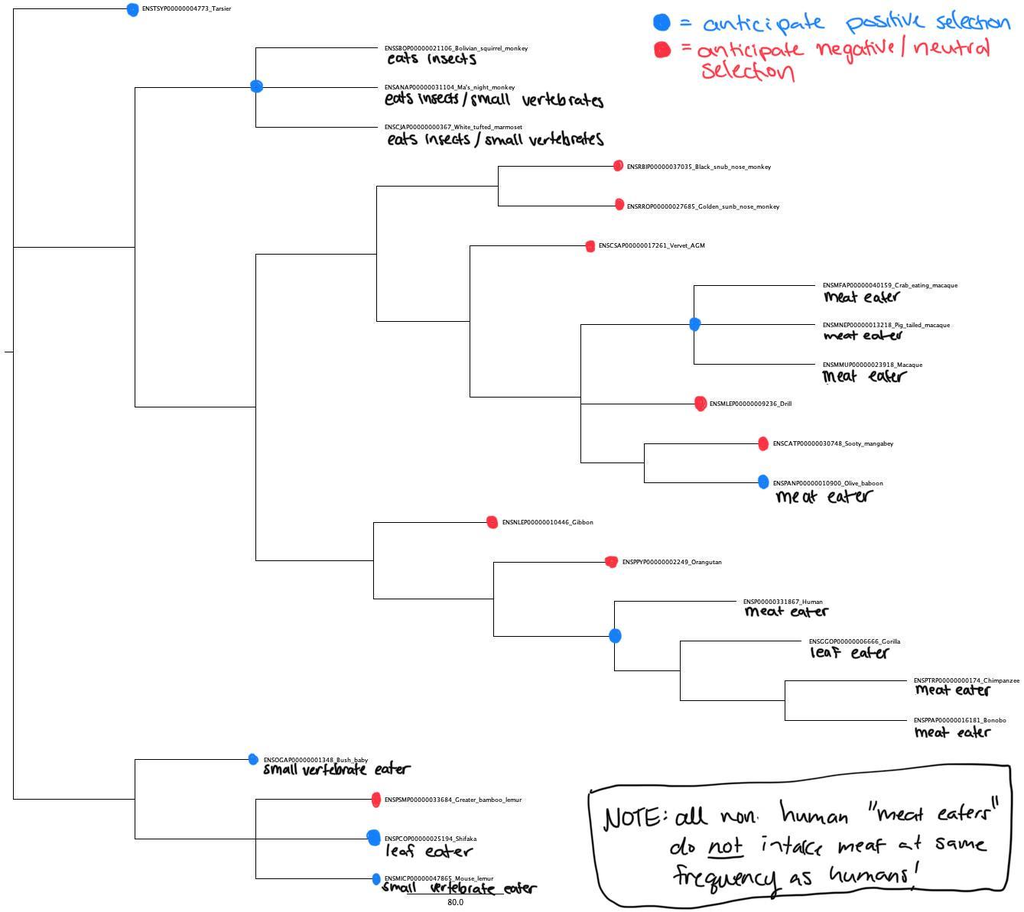

Anticipated results based on hypotheses

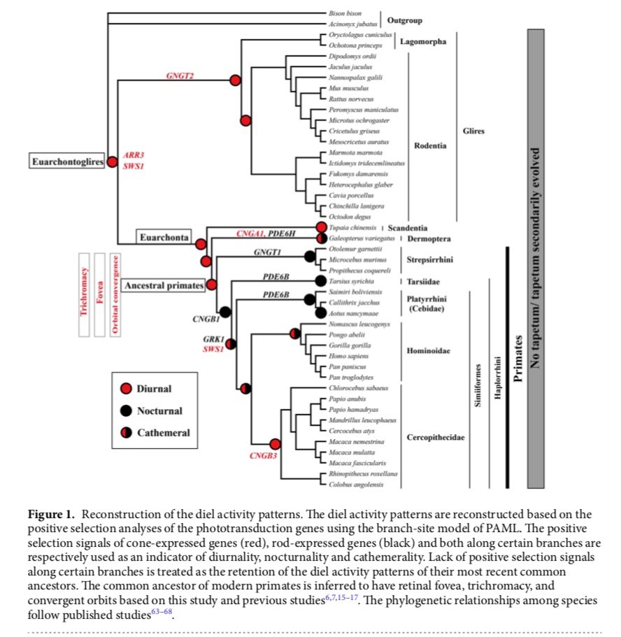

As this research has not been completed, I have shown an example of a similar phylogeny from Wu et al. which was a reconstruction of primate diel pattern using opsin genes. Using the results from my PAML analyses, I will create a similar phylogenetic tree where I mark branches with their respective selection symbol.

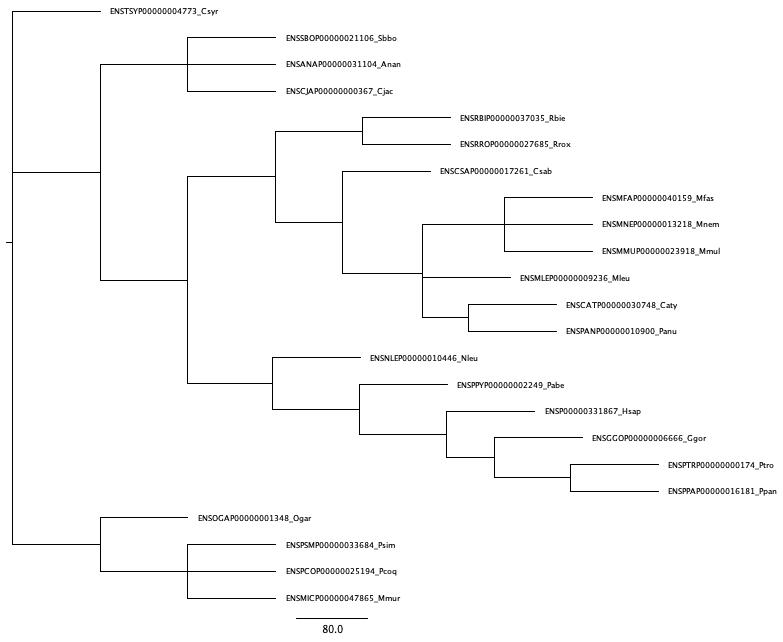

The maximum likelihood tree for the TAS1R1 gene

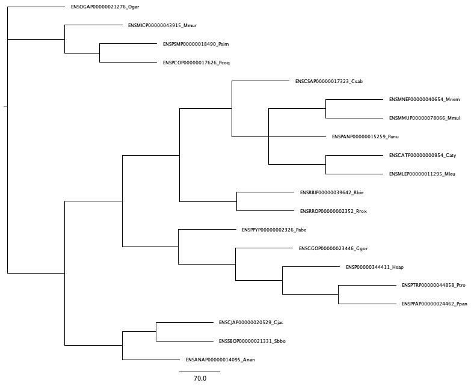

The maximum likelihood tree for the TAS1R3 gene

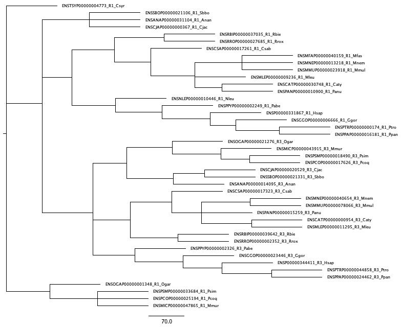

The maximum likelihood tree for both the TAS1R1 gene and the TAS1R3 gene when they were combined into a single file.